# Śledzie

# 7 Analiza atrybutów

Zbiór danych składa się z 15 atrybutów. Opisują one:

- długość złowionego śledzia (length),
- dostępność planktonu (cfin1, cfin2, chel1, chel2, lcop1, lcop2),
- narybek (fbar, recr, cumf),
- łączną liczbę złowionych ryb w ramach połowu (totaln)
- wodę (sst, sal, nao),
- miesiąc połowu (xmonth).

# 8 Sekcja sprawdzająca korelacje między zmiennymi

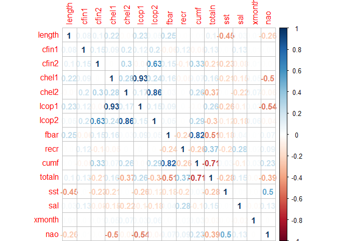

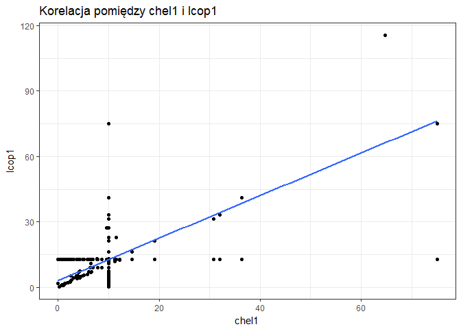

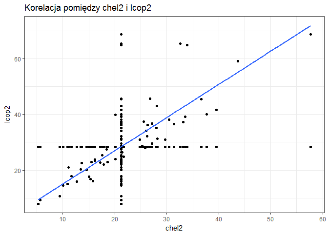

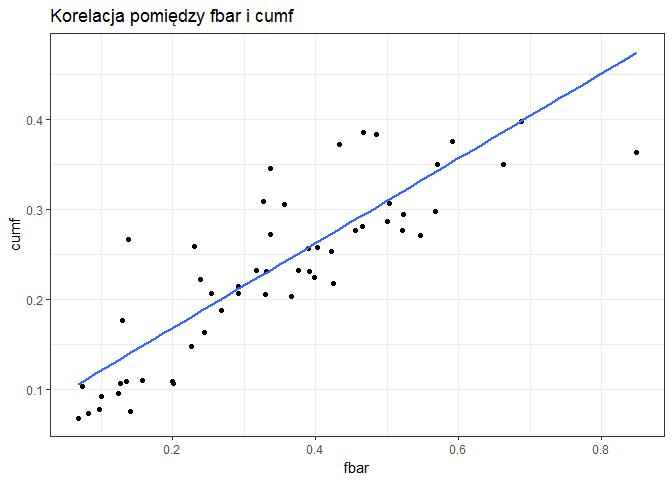

Z powyższych wykresów można zaobserwować, że najbardziej skorelowanyne ze sobą są pary atrybutów:

- chel1 i lcop1
- chel2 i lcop2
- fbar i cumf

Na tej podstawie możemy usunąć trzy atrybuty (chel1, chel2, fbar) z przetwarzanego zbioru danych/

# 9 Zmiana rozmiaru śledzia w czasie - wykres interaktywny

[interactive chart not shown]

# 10 Regresor przewidujący rozmiar śledzia

W naszym przypadku regresja ma za zadanie stworzyć model, który będzie przewidywał długość śledzi w czasie. Dane wejścopwe są oczyszczone z wartości pustych, a atrybuty chel1,chel2, fbar usunięte, ze względu na silną korelację. Zbiór danych podzielony został na dane uczące, walidujące i testowe. Tak przygotowe dane zostaną poddane procesowi uczenia przy pomocy algorytmu random forest.

Trafność rekgrasji została oszacowana na podstawie miar R<sup>2</sup> i RMSE.

| RMSE | 1.1627559 |
| --- | --- |
| Rsquared | 0.5132303 |

Poniższy wykres przedstawia przewidywaną zmianę długości śledzia w czasie.

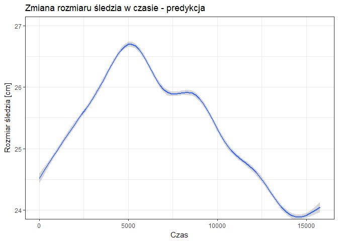

# 11 Analiza ważności atrybutów

```
## rf variable importance
##
##        Overall
## xmonth 100.000
## cfin2   27.299
## sst     19.903
## lcop2   19.400
## lcop1    9.163
## totaln   8.672
## sal      3.365
## cfin1    2.845
## cumf     1.035
## nao      0.308
## recr     0.000
```

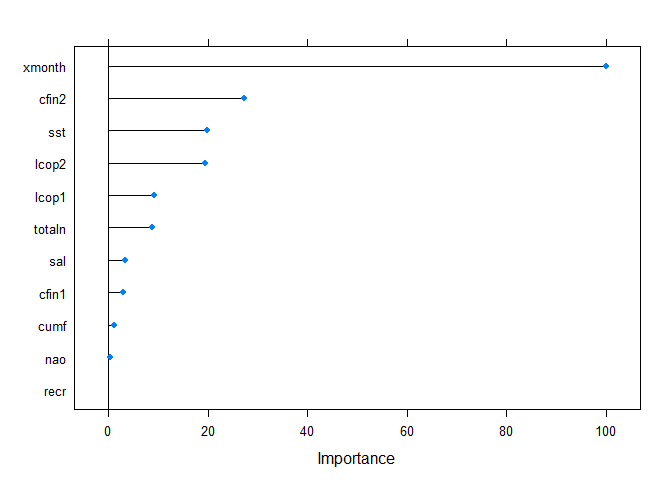